# A Deep Dive Into New York Real Estate

Unique Team B

4/25/2019

# Introduction to The Problem

- New York real estate data from 2003 to 2017
- Dataset can be found here: https://www1.nyc.gov/site/finance/taxes/property-annualized-sales-update.page
- Key questions:
  - What variables are most influential in determining sale price?
  - Is location really as big a determinant as we might think?
  - What kind of real estate is being sold?

# Description of the Data

- The dataset has 1432460 rows and 22 columns
- The major important outcome is the sale price
- Some informative predictors are location (borough and neighborhood) and year of sale

# Unexpected Values in Dataset

- Approach to tackle this problem
- 30% of properties are not priced
- reason could be change/transfer of ownership (quit claim deed))
- removing Year Built Values and Sale prices which are 0 for analysis purposes

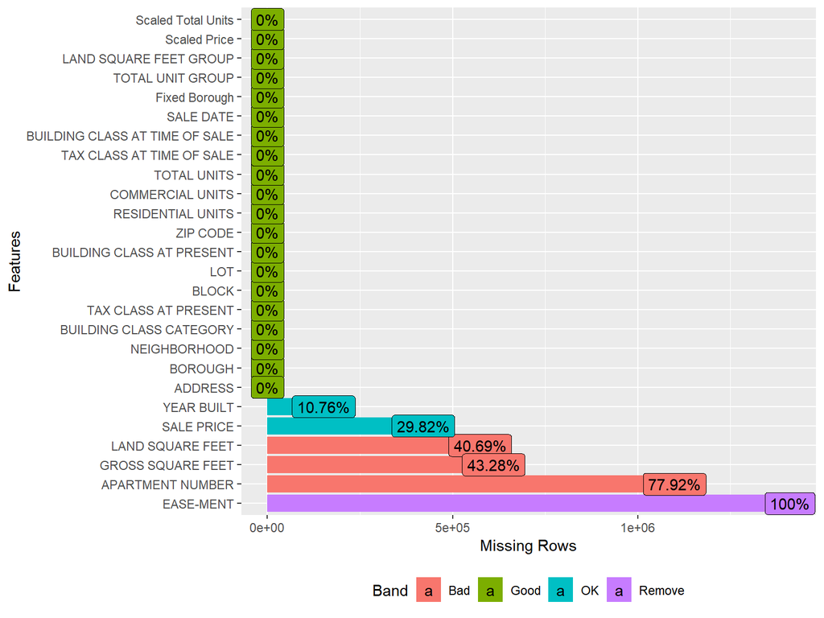

```
## [1] 25 26
```

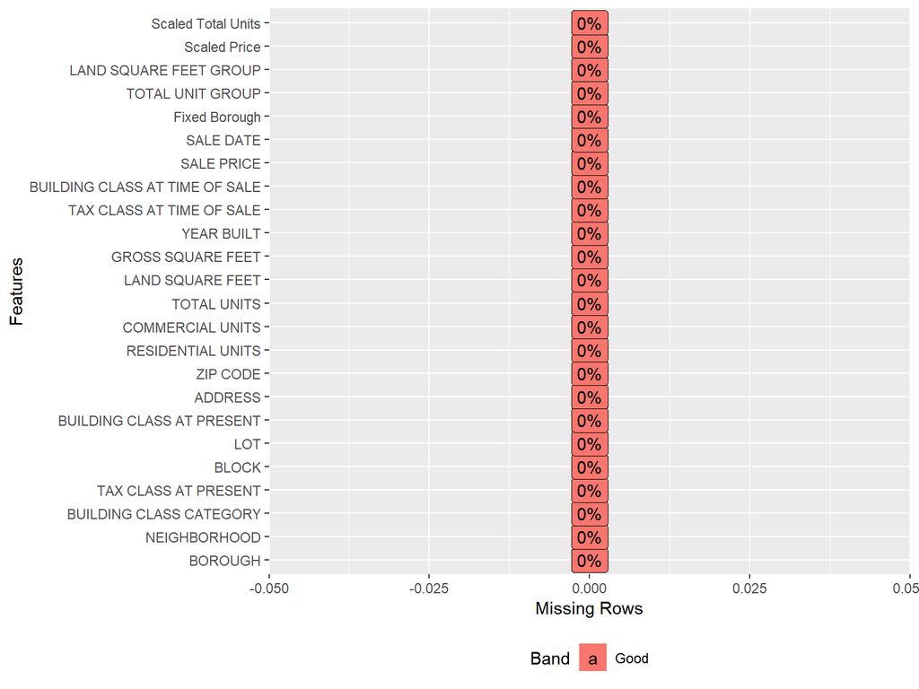

# Average Prices Through the Years

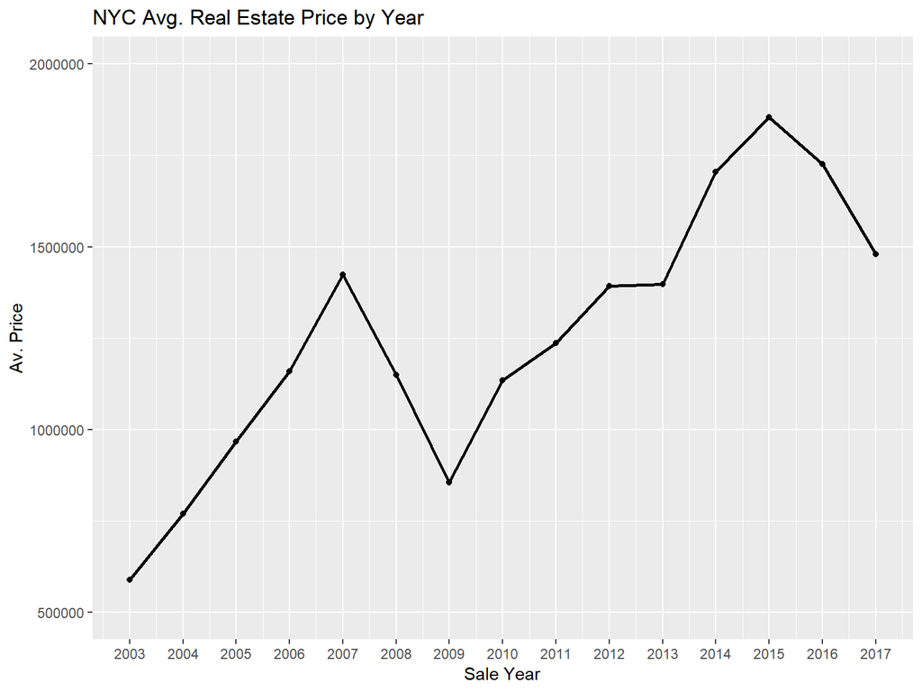

# Average Prices Through the Boroughs

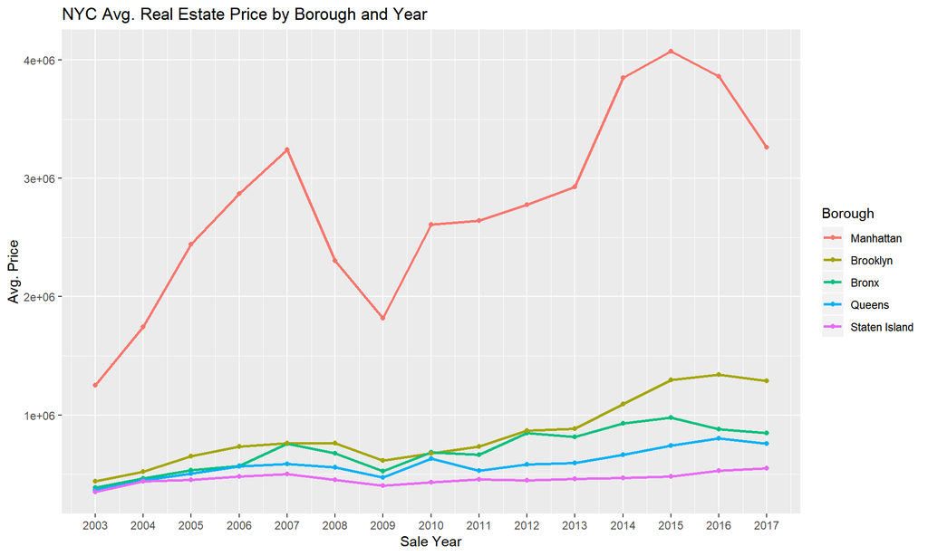

# Occurrences by Borough

|  | Fixed Borough | N |
| --- | --- | --- |
| 1 | Queens | 437742 |
| 2 | Brooklyn | 397307 |
| 3 | Manhattan | 355600 |
| 4 | Staten Island | 126601 |
| 5 | Bronx | 115210 |

# Sales per Year

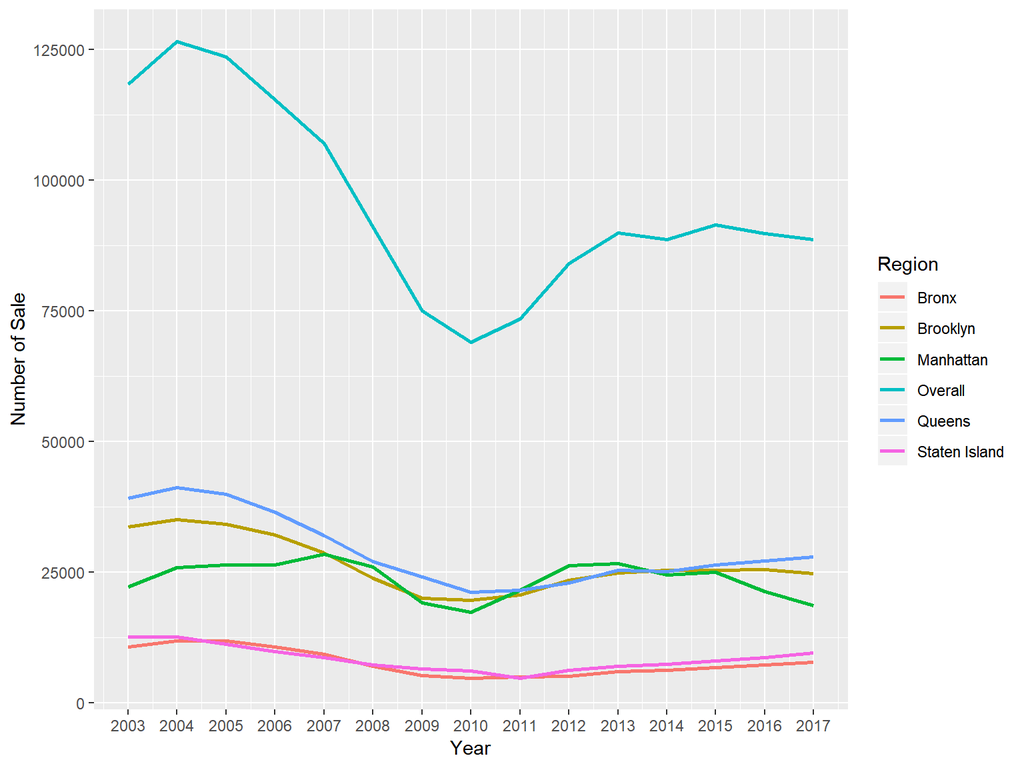

# Analyzing Sale Prices with respect to Month of Sale

|  | SALE MONTH | Mean Sale | N |
| --- | --- | --- | --- |
| 1 | 12 | 993340 | 126293 |
| 2 | 6 | 864622 | 135650 |
| 3 | 1 | 830903 | 111391 |
| 4 | 11 | 812198 | 111610 |
| 5 | 5 | 810769 | 121095 |
| 6 | 8 | 803293 | 128833 |
| 7 | 10 | 774416 | 119324 |
| 8 | 7 | 770813 | 122574 |
| 9 | 9 | 764356 | 117590 |
| 10 | 3 | 751745 | 121383 |

[output cut: 2 more lines]

# Binning Total Units and Land Square Feet

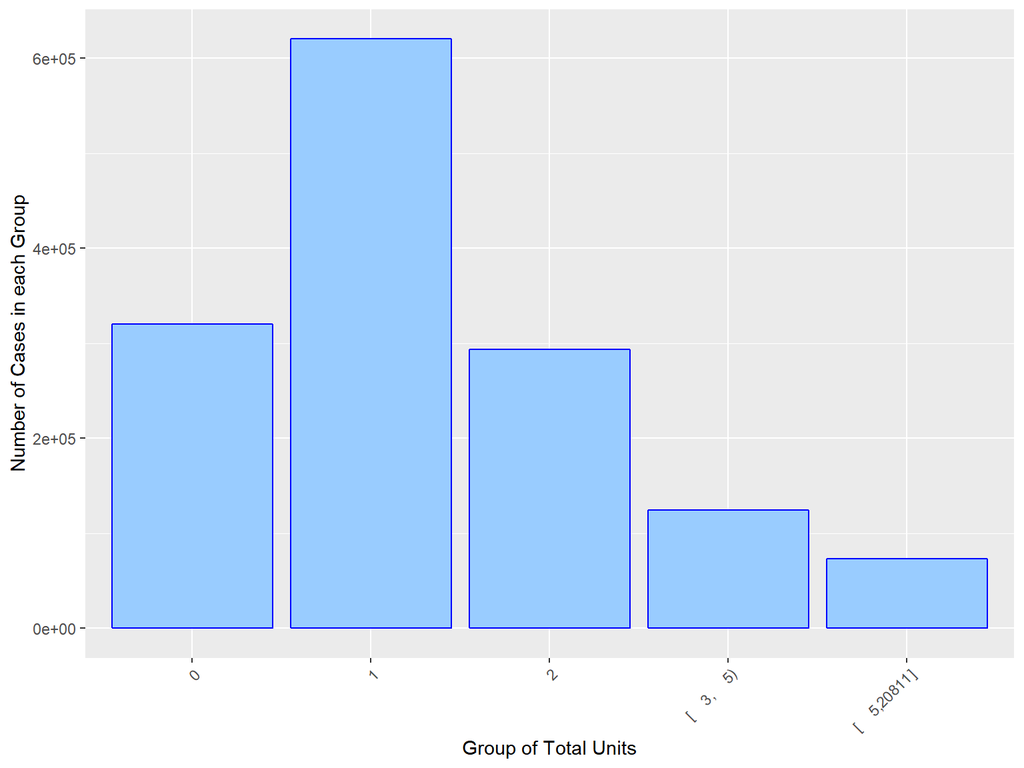

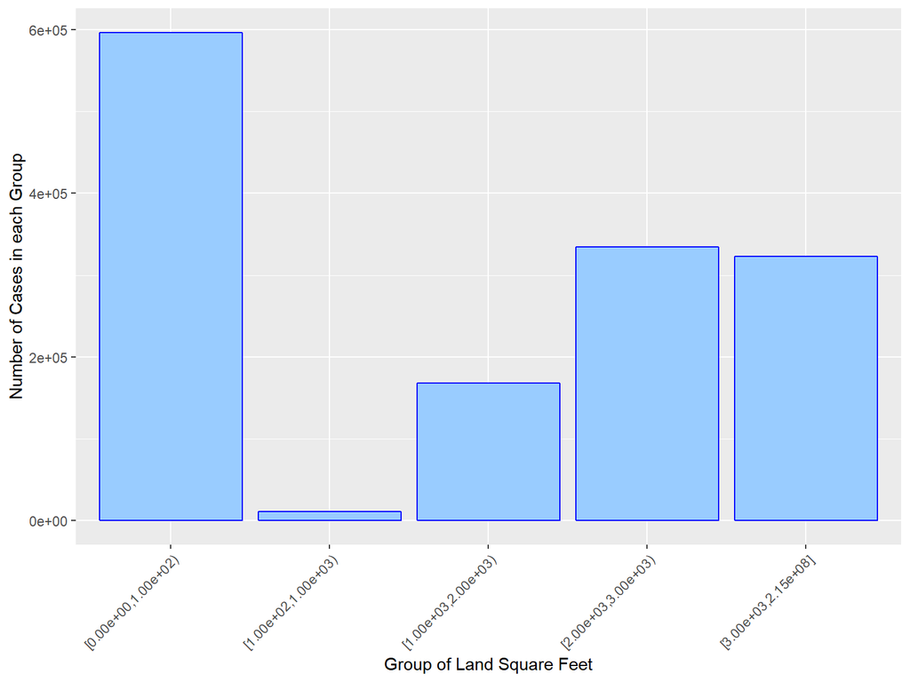

# Inspecting Logarithm of Price

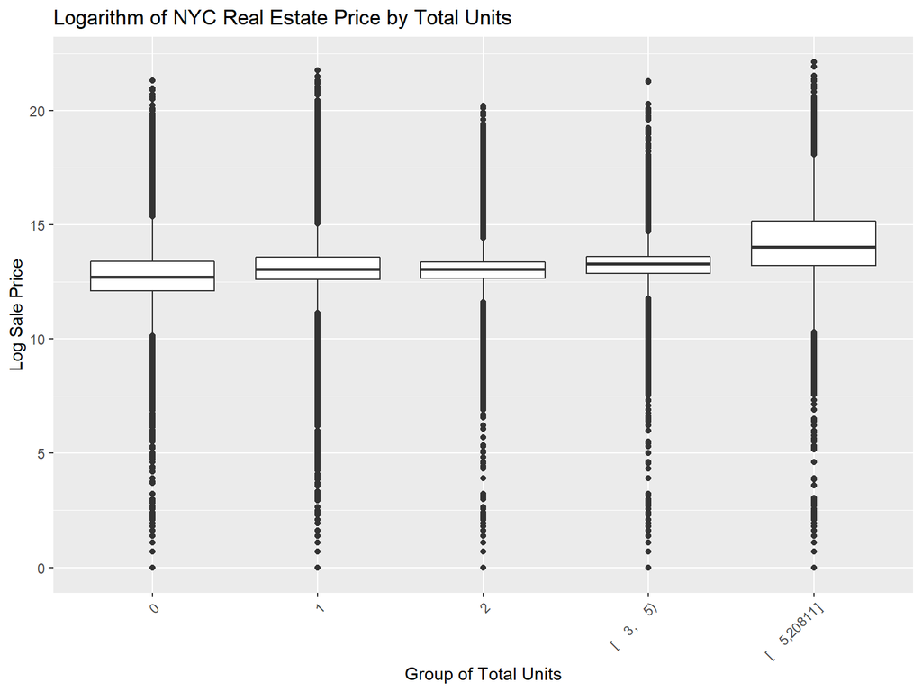

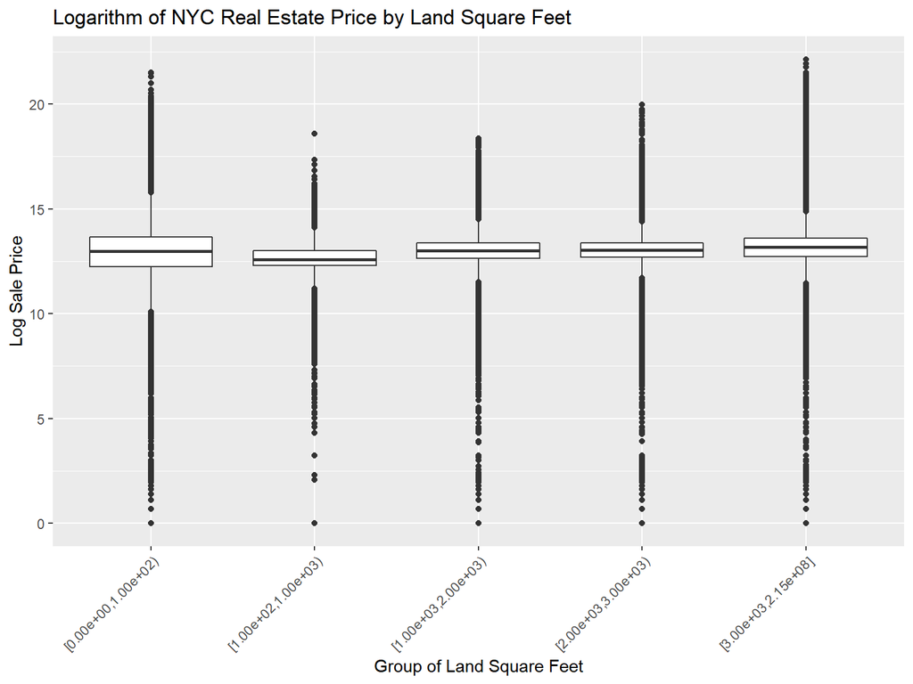

# Location, Location, Location

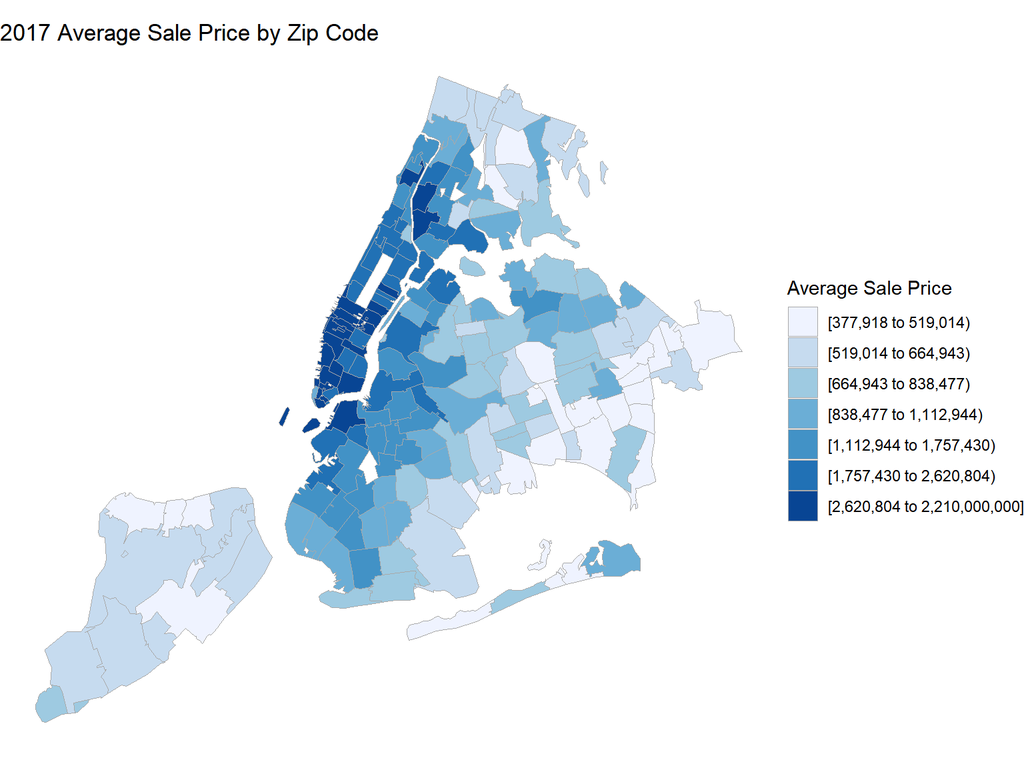

# Residential Properties

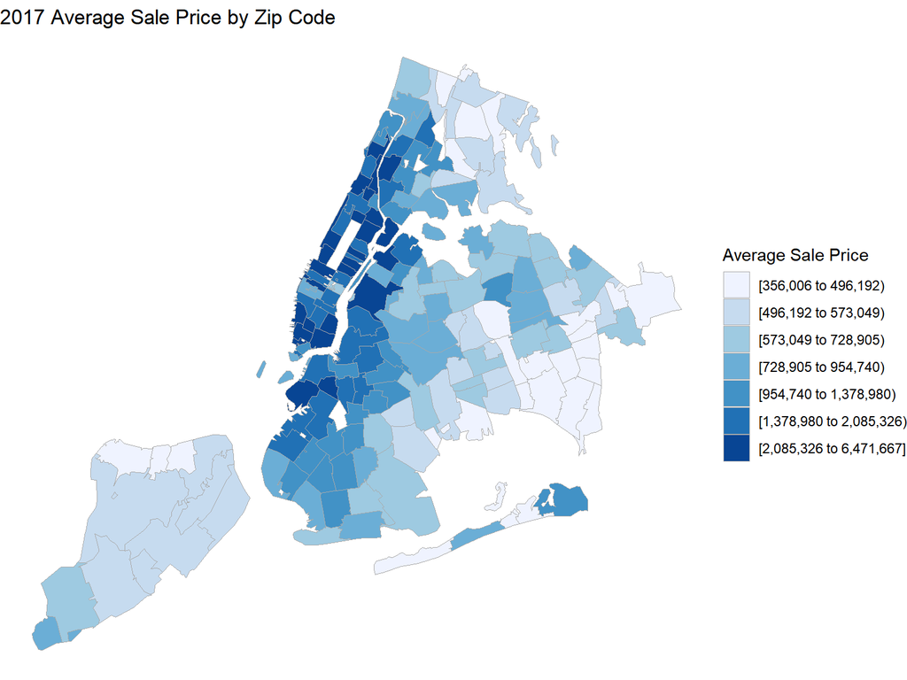

# Price per Square Footage by Borough

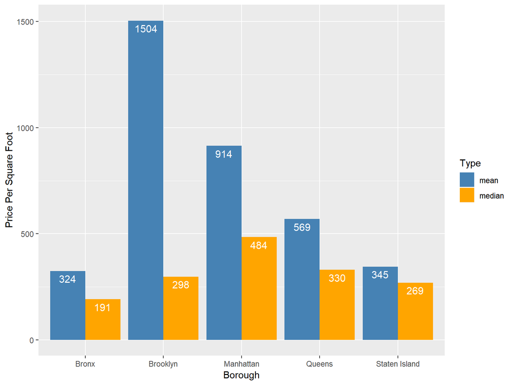

# Price per Square Footage by Year

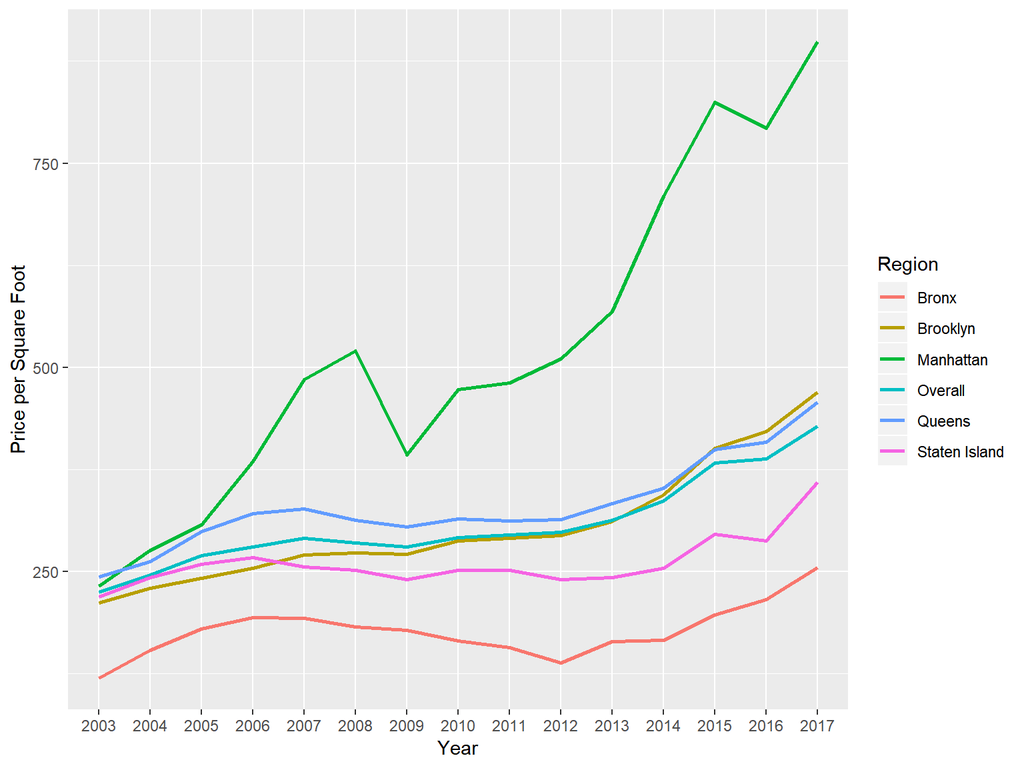

# Analyzing Neighborhoods in terms of their Sale Prices

|  | NEIGHBORHOOD | N | mean price |
| --- | --- | --- | --- |
| 1 | MIDTOWN CBD | 299 | 145051547 |
| 2 | KIPS BAY | 132 | 138007739 |
| 3 | FINANCIAL | 225 | 81608848 |
| 4 | TRIBECA | 161 | 38508381 |
| 5 | FASHION | 526 | 37280340 |
| 6 | FLATIRON | 271 | 33474816 |
| 7 | SOUTHBRIDGE | 66 | 25539315 |
| 8 | JAVITS CENTER | 87 | 22858547 |
| 9 | CHELSEA | 706 | 21979657 |
| 10 | DOWNTOWN-METROTECH | 56 | 21643878 |

[output cut: 252 more lines]

# Correlations

- Gross Square Feet and Sale price are correlated
- However, Land square feet and Sale price show weak correlation
- Total Units and Sale price also show a moderate correlation

|  | Land Square Feet and Sale Price | Gross Square Feet and Sale Price | Total Units and Sale Price |
| --- | --- | --- | --- |
| 1 | 0.01 | 0.475 | 0.436 |

# Correlation Between Price and Land Square Feet

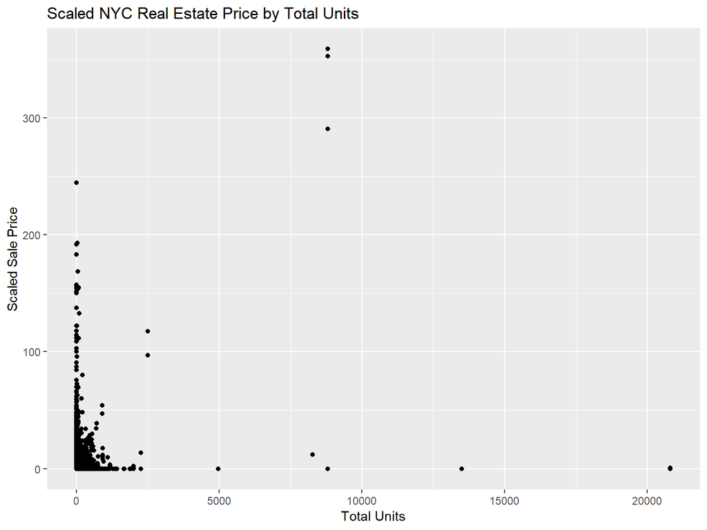

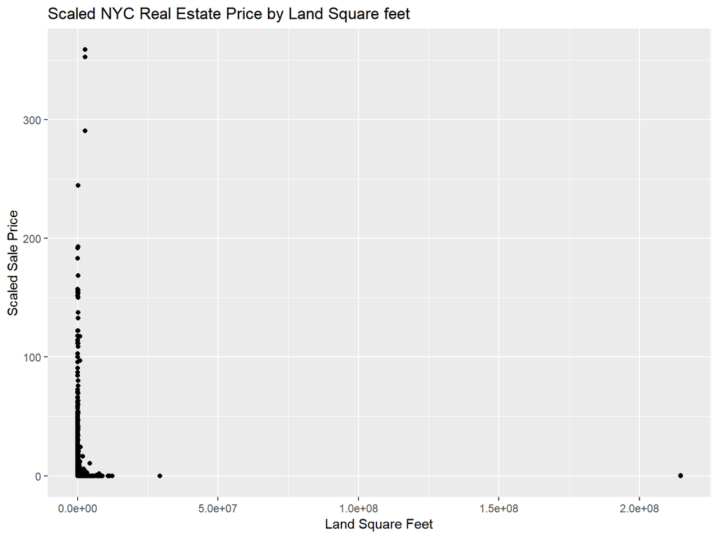

# Correlation on a Subset

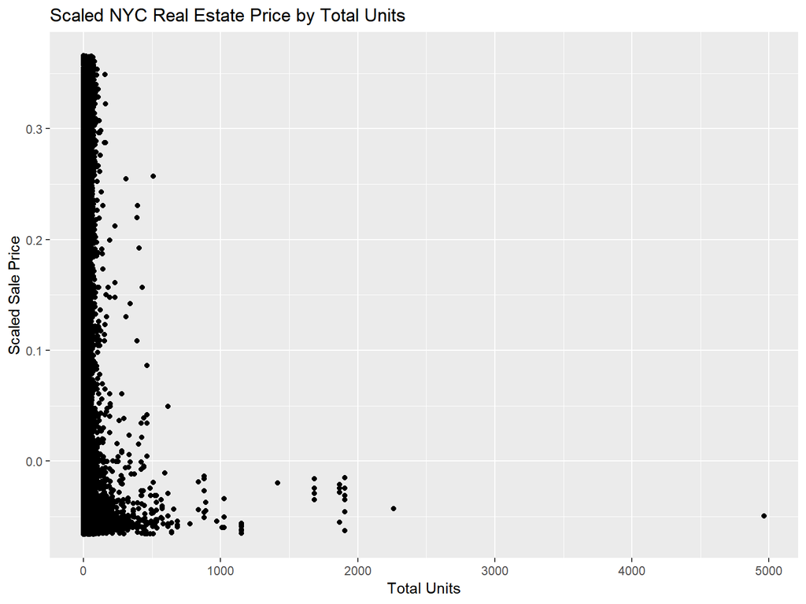

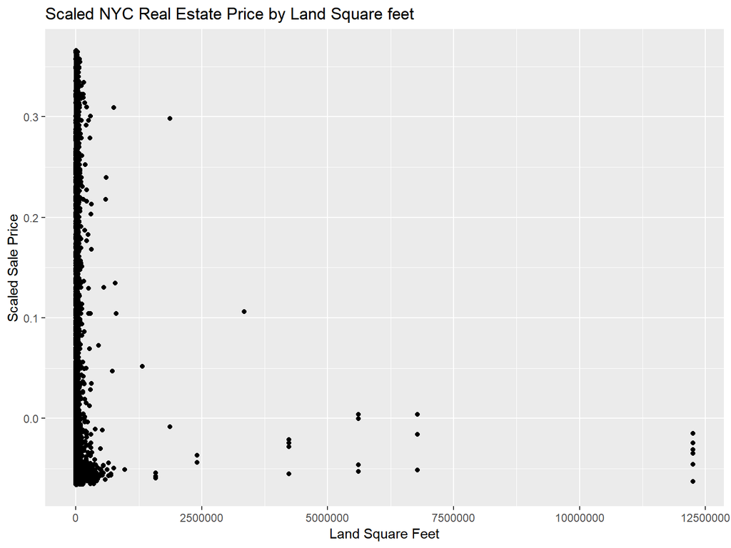

# Linear Regression Model with Selected Variables

```
##
## Call:
## lm(formula = `SALE PRICE` ~ `Fixed Borough` + `LAND SQUARE FEET` +
##     `GROSS SQUARE FEET` + `SALE YEAR` + `TOTAL UNITS` + `YEAR BUILT`,
##     data = train)
##
## Residuals:
##      Min       1Q   Median       3Q      Max
## -1.00805 -0.00925 -0.00027  0.00777  2.25961
##
## Coefficients:
##                                Estimate Std. Error t value Pr(>|t|)
## (Intercept)                  -5.612e+00  2.948e-01 -19.035  < 2e-16 ***
## `Fixed Borough`Brooklyn       2.190e-02  9.102e-04  24.062  < 2e-16 ***
## `Fixed Borough`Manhattan      3.688e-01  2.600e-03 141.827  < 2e-16 ***
## `Fixed Borough`Queens         1.100e-02  8.229e-04  13.365  < 2e-16 ***
## `Fixed Borough`Staten Island  3.676e-03  9.247e-04   3.976 7.03e-05 ***
## `LAND SQUARE FEET`            9.690e-07  8.411e-08  11.522  < 2e-16 ***
## `GROSS SQUARE FEET`           1.908e-05  2.724e-07  70.044  < 2e-16 ***
## `SALE YEAR`                   2.749e-03  1.463e-04  18.794  < 2e-16 ***
## `TOTAL UNITS`                -1.228e-02  4.544e-04 -27.019  < 2e-16 ***
## `YEAR BUILT`[1900,1925)      -1.715e-03  1.575e-03  -1.089  0.27632
## `YEAR BUILT`[1925,1950)      -2.176e-03  1.564e-03  -1.391  0.16414
## `YEAR BUILT`[1950,1975)      -9.125e-04  1.592e-03  -0.573  0.56653
## `YEAR BUILT`[1975,2000)      -5.414e-03  1.688e-03  -3.208  0.00134 **
## `YEAR BUILT`[2000,2017]      -3.836e-03  1.778e-03  -2.157  0.03100 *
## ---
## Signif. codes:  0 '***' 0.001 '**' 0.01 '*' 0.05 '.' 0.1 ' ' 1
##
## Residual standard error: 0.04251 on 42612 degrees of freedom
## Multiple R-squared:  0.4807, Adjusted R-squared:  0.4805
## F-statistic:  3034 on 13 and 42612 DF,  p-value: < 2.2e-16
```

|  | model.linear$Variable | Estimate | Pr(>\|t\|) |
| --- | --- | --- | --- |
| 1 | (Intercept) | -5.612 | 0 |
| 2 | `Fixed Borough`Brooklyn | 0.022 | 0 |
| 3 | `Fixed Borough`Manhattan | 0.369 | 0 |
| 4 | `Fixed Borough`Queens | 0.011 | 0 |
| 5 | `Fixed Borough`Staten Island | 0.004 | 0 |
| 6 | `LAND SQUARE FEET` | 0 | 0 |
| 7 | `GROSS SQUARE FEET` | 0 | 0 |
| 8 | `SALE YEAR` | 0.003 | 0 |
| 9 | `TOTAL UNITS` | -0.012 | 0 |
| 10 | `YEAR BUILT`[1900,1925) | -0.002 | 0.276 |

[output cut: 4 more lines]

# Implementation

- Many possible building types in the data, from one-family homes to airport terminals
- Building classes generally organized by first letter in “Building Class at Time of Sale” column

```r
all.data[, `Building Class First Letter` := substr(get(building.class.sale.name), 1, 1)]
```

# Limitations and Uncertainties

- Many rows of the dataset have prices that don’t make sense (ie. 0, 10, 100, etc.)
- It is never clear if a buyer bought the whole building, a few units, or only a single unit in the building
- Several building class types so a user should be aware of the difference in price range